# OHI data preparation

All data layers are prepared in the ohiprep_v20?? repository.

The best workflow is to prepare the layer or layers within a single Rmd script and then update the scores with these layers from the ohi-global repository. If only one layer is updated at a time it is much easier to identify and track potential errors.

This section will discuss: 1. File organization of the ohiprep_v20?? repository and the internal server, Mazu. 2. Preparing data for a new assessment year 3. A typical data prep script 4. Gapfilling datasets 5. Checking data layers

## File organization

### Saving external data

In almost all cases, OHI data comes from other institutions. We save these data to  
the NCEAS private server (Mazu) because we do not want to be responsible for serving other people’s data.

These data are saved to Mazu: git-annex/globalprep/_raw_data in a folder that is labeled with an abbreviated version of the datasource (Figure 1). The data is saved to a folder describing the year the data was downloaded (e.g., d2015, d2016).

Figure 1: Location of raw data saved to Mazu.

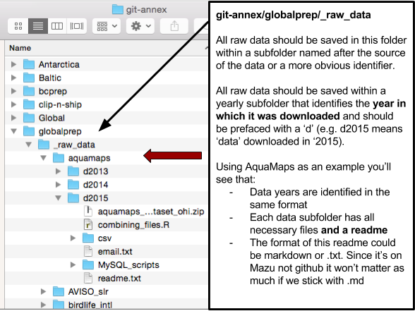

Every raw data folder should have a README.md (keep the caps so it is consistent and easy to see). *Note we are using .md rather than .txt even for READMEs on Mazu.

Each README should include the following ([template](https://github.com/OHI-Science/ohiprep/blob/master/src/templates/generic_raw_data_README.md)):

- Detailed source information. For example:
  - full paper citation and link for publication
  - Link to online data source
  - Full email history with data provider
- If it was downloaded online, provided written and visual instructions so that the reader can mimic your same steps to get the same data. Include screenshots if possible!
- Version information for data
- Years included in the datatset
- Year the data was published
- Type of data included in the dataset (e.g., catch per species (tons) per country)
- Any other information that could possibly be useful to anyone

### Preparing the data

All of the R scripts and metadata used to prepare the data, as well as the final data layers are saved in the Github ohiprep_v???? repository in the globalprep folder.

The only data that will not be saved on Github are files that are too large or incompatible with Github (see below).

**Primary goal/component folder** The folder should be named according to the OHI target (the goal or dimension that the data is used to calculate). For example the folder for the tourism and recreation goal would be called: globalprep/tr (see table below). These recommendations are flexible and should be modified as needed, for example goals can be combined in a single folder (e.g., spp_ico) or, there may be several folders for different components of a single goal (e.g. tr_sustainability and tr_tourists).

| target | suggested folder name |
| --- | --- |
| Artisanal Fishing Opportunity | ao |
| Carbon Storage | cs |
| Clean Waters | cw |
| Coastal Protection | cp |
| Coastal Livelihoods | liv |
| Coastal Economies | eco |
| Fisheries | fis |
| Habitats | hab |
| Iconic Species | ico |
| Lasting Special Places | lsp |
| Mariculture | mar |
| Natural Products | np |
| Species | spp |
| Tourism and Recreation | tr |
| Pressure | prs_*additional_pressure_id* |
| Resilience | res_*additional_resilience_id* |

This folder will contain:

- a *README.md* that will link to the appropriate information pages on ohi-science.org The README.md should follow this [template](https://github.com/OHI-Science/ohiprep/blob/master/src/templates/generic_readme.md).
- **Year-specific folders** within the goal/component folder organize output by assessment year (v2015, v2016). Each of the assessment year folders should have:
  - a README.md (see [this template](https://github.com/OHI-Science/ohiprep/blob/master/src/templates/generic_readme_year.md))
  - a data_prep.R, or .Rmd that is well-documented. [Here is the dataprep template](https://github.com/OHI-Science/ohiprep/blob/master/src/templates/generic_data_prep.Rmd).
  - a series of folders to organize data that include:
    - `raw` for ‘raw-ish’ type files that would not be on the server. This is typically for piecemeal raw data that we compile (e.g., U.S. State Department travel warnings), and not data we have downloaded from a single source (which would go on Mazu). In most cases, this folder will not be used.
    - `int` for intermediate files (previously we’ve used tmp, working, or other naming conventions so this might not be entirely consistent).
    - `output` for the final data layer that is used in the OHI toolbox.

The final datasets (the ones stored in the `output` folder) will be preceeded by the target abbreviation followed by an underscore that provides a brief description of the data, e.g., tr_sustainability.csv).

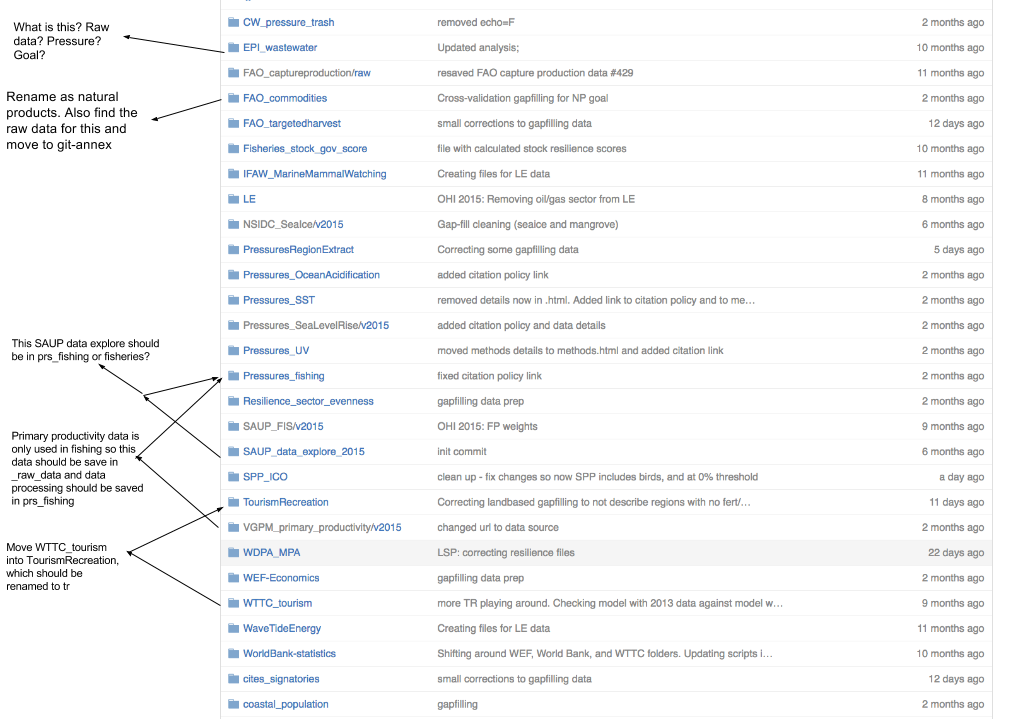

### Dealing with intermediate files that are too large for Github

These files will be saved on Mazu, the internal server’s, globalprep folder.

Our goal is to have everything (except for data obtained from other sources) stored on GitHub, but some files are too large or inappropriate for GitHub and must be stored on Mazu. Each of these files should be stored in a way that mirrors that on Github. If there is a need to make a duplicate folder on `git-annex`, it should have the same name as the folder used in GitHub.

[figure not shown]

Store any intermediate or final output files that are too large for github in these folders. Keep the same subfolder structure. If you are working in `spp_ico` and have temporary rasters to store on Mazu, save them in a folder named `int`.

**Raw data should not be stored here. This should be stored in Mazu’s `_raw_data` folder**

## Beginning a new assessment year

In ohiprep_v20??/globalprep navigate to the folder that contains the files you will need to prepare the data. Select the most recent assessment year of data and copy the folder and paste to the same location, changing the name to reflect the current assessment year.

For example, if we are preparing data layers for the 2019 assessment for the artisanal opportunities goal, ao, we would copy the v2018 folder and name it v2019.

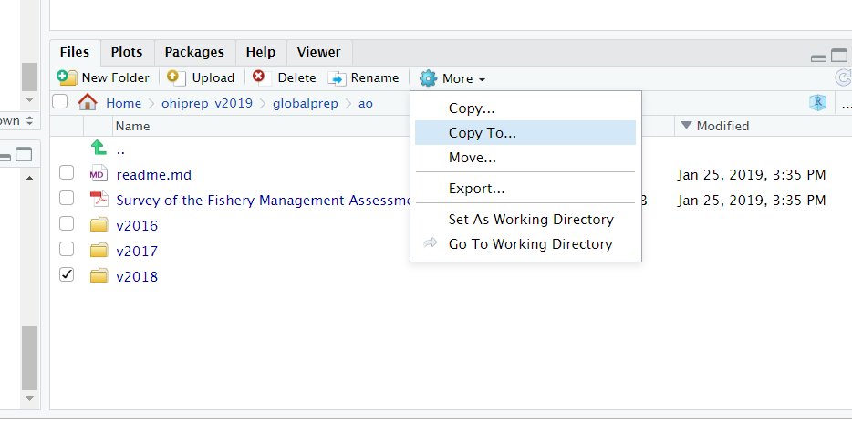

IMPORTANT: Delete the files in the raw, intermediate, and output files! These data will be created in the updated data_prep script.

You will then walk through the data_prep script and update it as necessary.

## A typical data prep script

All data prep is performed in R or, preferrably, Rmd documents. Rmd is an ideal format because it seemlessly integrates code and documentation, can display figures, and the output provides a clean methods document.

We have several shared practices for preparing data:

- Ideally Rmd/R files are used to download and save source datafiles, but this isn’t possible in most cases due to the format of the data.
- We put a large premium on documenting the steps used to prepare data!
- In many cases, the data preparation for a goal is performed in a single file. But, for more complex goals it is better to break the data preparation into multiple Rmd documents. If multiple Rmd documents are used, a README must describe what each Rmd document does, the input/outputs, and the order of processing.
- If a process is run multiple times, the code should be converted to a function and placed in folder labeled R or src.
- The `here` package, and `here()` function should be used control file paths.
- We use the tidyverse for tidying data

A typical data prep script (or series of scripts) will include the following sections, which are described in more detail below:

1. Script summary: general description of what the script does
2. Updates: updates to source data and/or methods from previous year
3. Data sources: description of source data
4. Set up code: code chunk that loads relevant R packages and functions
5. Data prep: code chunks used to prepare the data, this is typically the bulk of the Rmd file
6. Gapfilling: code chunks used to estimate and document missing data
7. Data check: code used to check data
8. Saving final data layers and gapfilling data

A generic data prep Rmd file is located on Github: github.com/OHI-Science/ohiprep_v2019/workflow/templates/generic_data_prep.Rmd

## prep Rmd: 1. Script summary

This section describes the purpose of the script and the data layers that are generated.

## prep Rmd: 2. Updates

This sections describes all the updates to source data and/or methods since the previous year’s assessment.

## prep Rmd: 3. Data sources

This sections describes the datasources and may include:

**Reference**: [citation for source data; website, literature, contact information. Version of data (if relevant).]

**Downloaded**: [date downloaded or received]

**Description**: [e.g., surface aragonite state]

**Native data resolution**: [e.g., 1 degree, 30 m, country, etc.]

**Time range**: [e.g., 1880-1899, monthly data provided for each year]

**Format**: [e.g., NetCDF, Excel file]

## prep Rmd: 4. Set up code

This code chunk is used to load packages, source functions, and set variables that are used throughout the analyses.

### Packages

The packages we load depend on the analyses, but we always use: * dplyr and tidyr: data wrangling tools (a cheatsheet: https://www.rstudio.com/wp-content/uploads/2015/02/data-wrangling-cheatsheet.pdf) * here: controlling file paths (https://github.com/jennybc/here_here)

We often use the following for spatial analyses: * sp: classes and methods for spatial data * rgdal: tools for dealing with coordinate reference systems * raster: reading, writing, manipulating, analyzing and modeling of gridded spatial data * fasterize: a better way to convert a shapefile to a raster file * sf: a standardized way to encode spatial vector data

We often use the zoo package for time-series data.

And, if we do parallel processing we use: * doParallel * foreach

### common.R

Nearly all scripts will source a common.R file. This file creates several objects that make it easier to conduct an OHI assessment. This includes:

| object | description |
| --- | --- |
| dir_M | file path to Mazu |
| mollCRS | crs code for the mollweide coordinate refernce system we use in the global assessment |
| regions_shape() | A function to load a simple feature object called “regions” with polygons for land/eez/highseas/antarctica regions. The “regions” object uses the Mollweide coordinate reference system. |
| ohi_rasters() | function to load two rasters: global eez regions and ocean region |
| rgn_data() | function to load 2 dataframes describing global regions |
| rgn_syns() | function to load dataframe of region synonyms (used to convert country names to OHI regions) |
| low_pop() | function to load dataframe of regions with low and no human population |
| UNgeorgn() | function to load dataframe of UN sociopolitical regions, typically used to gapfill missing data |

To load the data in a data function:

```r
source('http://ohi-science.org/ohiprep_v2019/workflow/R/common.R')
```

```
## This file makes it easier to process data for the OHI global assessment
##  by creating the following objects:
##
##  * dir_M = identifies correct file path to Mazu (internal server) based on your operating system
##  * mollCRS = the crs code for the mollweide coordinate reference system we use in the global assessment
##  * regions_shape() = function to load global shapefile for land/eez/high seas/antarctica regions
##  * ohi_rasters() = function to load two rasters: global eez regions and ocean region
##  * region_data() = function to load 2 datatables describing global regions
##  * rgn_syns() = function to load datatable of region synonyms (used to convert country names to OHI regions)
##  * low_pop() = function to load datatable of regions with low and no human population
##  * UNgeorgn = function to load UN geopolitical designations used to gapfill missing data
```

```r
# call the function to load the data, the message describes the available data:
region_data()
```

```
## loads 2 datatables: rgns_all and rgns_eez
##  rgns_all = includes eez/high seas/antarctica regions, IDs correspond with region shapefile and raster
##  rgns_eez = includes only eez regions
```

```r
head(rgns_all)
```

```
##   rgn_type type_w_ant rgn_id rgn_ant_id              rgn_name
## 1      eez        eez      1          1         Cocos Islands
## 2      eez        eez     10         10                 Nauru
## 3      eez        eez    100        100   Republique du Congo
## 4      eez        eez    101        101               Namibia
## 5      eez        eez    102        102          South Africa
## 6      eez        eez    103        103 Sao Tome and Principe
```

```r
head(rgns_eez)
```

```
##   rgn_id         rgn_name eez_iso3 territory admin_rgn_id
## 1      1    Cocos Islands      CCK       yes           16
## 2      2 Christmas Island      CXR       yes           16
## 3      3   Norfolk Island      NFK       yes           16
## 4      4 Macquarie Island      AUS       yes           16
## 5      5    New Caledonia      NCL       yes          179
## 6      6          Vanuatu      VUT        no            6
##   admin_country_name Notes
## 1          Australia
## 2          Australia
## 3          Australia
## 4          Australia
## 5             France
## 6            Vanuatu
```

#### metadata for common.R

*dir_M and mollCRS*

The following are the dir_M and mollCRS objects:

```r
## dir_M describes the path to our internal server based on your computer's operating system
## NOTE: The following may be different on your operating system
dir_M
```

```
## [1] "/home/shares/ohi"
```

```r
## mollCRS is the code for the Mollweide coordinate reference system
mollCRS
```

```
## CRS arguments:
##  +proj=moll +lon_0=0 +x_0=0 +y_0=0 +ellps=WGS84 +units=m +no_defs
```

*regions_shape* The regions_shape function returns a simple feature object called “regions”. Regions is the master global shapefile that includes polygons for land, eez, high seas, and antarctica regions in the Mollweide coordinate reference system.

Sometimes it is necessary to convert from a simple feature object to a shapefile object because some functions do not work with simple feature objects. This is accomplished like this:

`regions_shape <- as(regions, "Spatial")`

The regions file with eez (dark blue), fao or high seas (light blue), and antarctica or CCAMLR (green) regions.

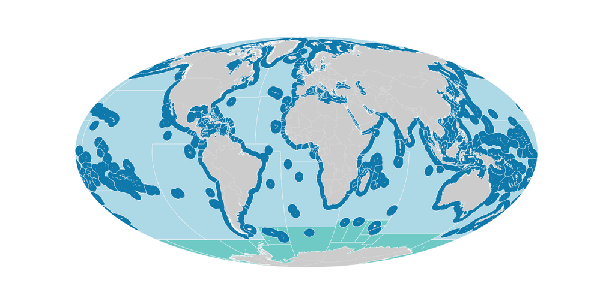

The regions object is a simple feature multipolygon spatial object in the Mollweide coordinate reference system. There are 7 fields described in the table

| field | data type | description | examples |
| --- | --- | --- | --- |
| type_w_ant | factor | identifies all polygons as eez, fao (high seas), ccamlr (antarctica), or land | eez (n=220), fao (15), eez-ccamlr (19), land (220), land-ccamlr (9), eez-disputed (1), land-disputed (1), eez-inland (3), land-noeez (38) |
| rgn_type | factor | similar to type_w_ant, but does not specify eez/ccamlr and land/land-ccamlr regions | eez (n=239), fao (15), land (229), eez-disputed (1), land-disputed (1), eez-inland (3), land-noeez (38) |
| rgn_ant_id | numeric | region ids | 1-250 country land and eez (these are the official global regions; some numbers are skipped); 255 disputed land and eez; 260-277 fao high seas; 301-337 (country land, no eez); 248100-288300 CCAMLR reg… |
| rgn_id | numeric | region ids; similar to rgn_ant_id, but Antartica/CCAMLR regions lumped as region 213 | 1-250 country land and eez (these are the official global regions; some numbers are skipped); 255 disputed land and eez; 260-277 fao high seas; 301-337 (country land, no eez) |
| rgn_name | character | country/territory name | e.g., Afghanistan, Belize, Prince Edward Islands |
| rgn_key | factor | 3 letter identification code | e.g., AFG, BEL |
| area_km2 | numeric | area of region, km2 | range of 1-30604795 |

*ohi_rasters* The ohi_rasters function returns two rasters, “zones” and “ocean”, both with ~1 km resolution and the mollweide coordinate reference system.

The “zones” raster cell values are the OHI region ID. The raster cell values can be linked to the region names using the region_data() function, and the rgn_ant_id variable from rgns_all.csv. This raster is typically used to extract pressure data for the eez regions.

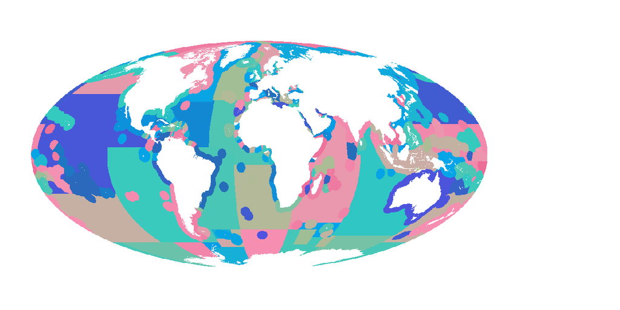

The “ocean” raster identifies ocean cells with a value of 1, and other cells are NA [NOTE: There is something weird about this raster in that it lists the values as 0, 255 (min, max), when in fact there are only 1 and NA values! If you need to convince yourself of this, you can use the `freq(ocean)` function to identify all cell values.]. This raster file is typically used to mask the ocean regions for pressure data.

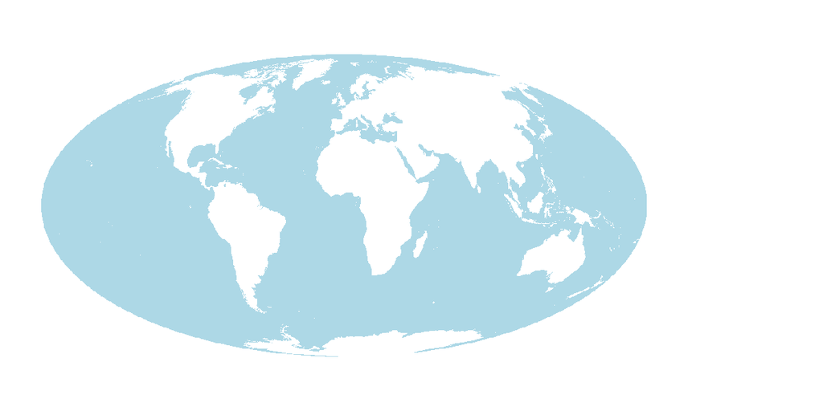

*region_data()* The region_data function returns two dataframes, “rgns_all” and “rgns_eez”.

The “rgns_all” dataframe includes data for the eez, fao, and ccamlr ocean regions. The IDs in rgn_ant_id correspond to the IDs in the zones raster. Once raster data are extracted for each region, the output is often aligned with the data in this dataframe.

The “rgns_eez” dataframe includes data for the 220 OHI regions plus Antarctica (rgn_id 213). This file is used to make sure that all regions are included in dataprep files. It also includes data to indicate whether regions are territories. This can also be used for gapfilling (in some cases, it makes sense to assign territories the same value as their administrative country).

*region_syns()* Observed synonyms for each region, such that each region may have multiple synonyms. These data are used to convert outside data to the OHI region name and ID. This list is updated nearly everytime we run an assessment!

*low_pop()* Includes data for 21 regions with 0 and low populations. These data are used to identify regions that should have NA values because the goal does not apply to regions with no/low populations (e.g., livelihoods and economies).

*UNgeorgn()* Each global regions UN georegion based on social and geopolitical considerations.

## prep Rmd: 5. Data prep

There are usually many code chunks used to prepare the data. There should be an introduction proceeding each code chunk describing what the code chunk accomplishes.

Within the code chunk: please spend time documenting the code to make it easier to follow and to help prevent errors. Describe what each section is doing. Document expected values and results (e.g., check to see all values between 0-1, length should be 0, etc.). Avoid run-on dplyr chains, these are impossible to follow and very prone to error!

The final output should be a dataframe that includes:

- *rgn_id* All 220 regions should be included in the final file!
- *year* This should include all years of data necessary to calculate scores for all scenario years, including trend. For some data layers the data has never been updated, in these cases, there is still a year column but it may only contain a single year.
- *value* This column will contain the calculated value for the data, and the column name will vary across datasets. In general, naming conventions should be consistently used every year, but feel free to modify the column name if you feel it could be improved. Just be sure to make the corresponding change to the “name_data_fld” in this file: https://github.com/OHI-Science/ohi-global/blob/draft/eez_layers_meta_data/layers_eez_base.csv.

This file should be saved as a .csv file in an “output” folder.

We make every effort to gapfill missing data. The only legitimate reason for a region to have an NA value is if the goal is not relevant to the region. For example, the livelihoods and economies goal is not relevant for an uninhabited island.

We have published an entire paper describing why and how we estimate missing data: https://journals.plos.org/plosone/article?id=10.1371/journal.pone.0160377. But I’ll give you the short version.

The first step to gapfilling missing data is to identify datasets that are predictive of the variable you are attempting to estimate and is also more complete. Here are some of the general approaches we use to estimate missing global data: